# Annexes codes de mon devoir stats de base

ALOKEME Israel

2026-10-07

## Appel de librairies, choix du répertoire de travail et codificatio des variables

```r
library(tidyverse)
library(gtsummary)
setwd("F:/alokeme/M2 Stats/Devoirs/Stats de base")
mabase_reti <- read.csv2("TPretinol.csv",header = T)
mabase_reti$tabac <- as.factor(mabase_reti$tabac)
mabase_reti$vitamine <- as.factor(mabase_reti$vitamine)
mabase_reti$sexe <- as.factor(mabase_reti$sexe)
```

## 1: Résumé statistique de la base de données

```r
tbl_summary(mabase_reti,
            include = c("age", "sexe", "tabac", "bmi", "vitamine","cholesterol", "alcool", "retdiet", "retplasma"),
            type = list(all_continuous()~"continuous2"),
            statistic = list(
              all_continuous() ~ c("{median} ({p25}, {p75})","{mean}", "{min}, {max}", "{sd}" ),
              all_categorical() ~ ("{n} {p}%")
            ))
```

| **Characteristic** | **N = 315**<sup>1</sup> |
| --- | --- |
| age |  |
| Median (Q1, Q3) | 48 (39, 63) |
| Mean | 50 |
| Min, Max | 19, 83 |
| SD | 15 |
| sexe |  |
| 1 | 42 13% |
| 2 | 273 87% |
| tabac |  |
| 1 | 157 50% |
| 2 | 115 37% |
| 3 | 43 14% |
| bmi |  |
| Median (Q1, Q3) | 24.7 (21.8, 28.9) |
| Mean | 26.2 |
| Min, Max | 16.3, 50.4 |
| SD | 6.0 |
| vitamine |  |
| 1 | 122 39% |
| 2 | 82 26% |
| 3 | 111 35% |
| cholesterol |  |
| Median (Q1, Q3) | 206 (155, 309) |
| Mean | 242 |
| Min, Max | 38, 901 |
| SD | 132 |
| alcool |  |
| Median (Q1, Q3) | 0.3 (0.0, 3.2) |
| Mean | 3.3 |
| Min, Max | 0.0, 203.0 |
| SD | 12.3 |
| retdiet |  |
| Median (Q1, Q3) | 707 (479, 1,047) |
| Mean | 833 |
| Min, Max | 30, 6,901 |
| SD | 589 |
| retplasma |  |
| Median (Q1, Q3) | 566 (466, 719) |
| Mean | 603 |
| Min, Max | 179, 1,727 |
| SD | 209 |

<sup>1</sup> n %

## 2: Etudier les relations entre toutes les paires de variable possibles

## Tous les histogrammes de normalité en une seule figure

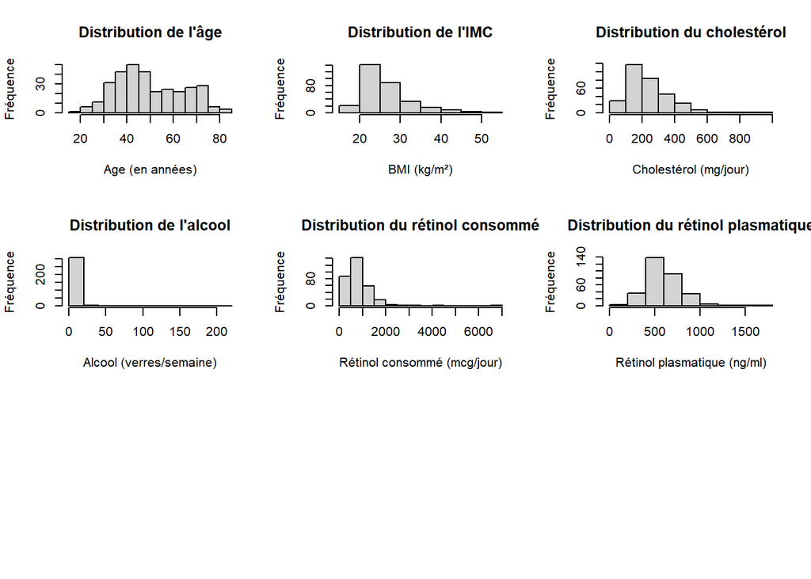

```r
par(mfrow = c(3, 3))
hist_1 <- hist(mabase_reti$age, xlab = "Age (en années)", ylab = "Fréquence", main = "Distribution de l'âge")
hist_2 <- hist(mabase_reti$bmi, xlab = "BMI (kg/m²)", ylab = "Fréquence", main = "Distribution de l'IMC")
hist_3 <- hist(mabase_reti$cholesterol, xlab = "Cholestérol (mg/jour)", ylab = "Fréquence", main = "Distribution du cholestérol")
hist_4 <- hist(mabase_reti$alcool, xlab = "Alcool (verres/semaine)", ylab = "Fréquence", main = "Distribution de l'alcool")
hist_5 <- hist(mabase_reti$retdiet, xlab = "Rétinol consommé (mcg/jour)", ylab = "Fréquence", main = "Distribution du rétinol consommé")
hist_6 <- hist(mabase_reti$retplasma, xlab = "Rétinol plasmatique (ng/ml)", ylab = "Fréquence", main = "Distribution du rétinol plasmatique")
```

## a : Entre la concentration en rétinol et l’age

## Graphique

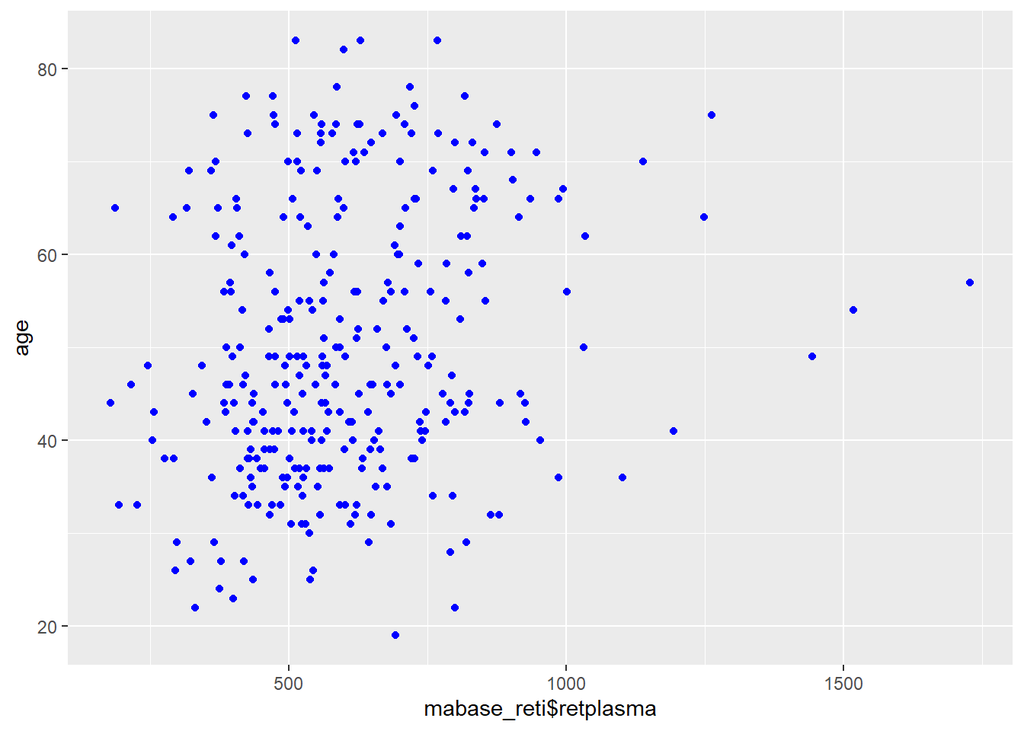

```r
ggplot(mabase_reti,aes(x=mabase_reti$retplasma, y= age)) + geom_point(col="blue")
```

## Verification de la normalité de la concentration en rétinol

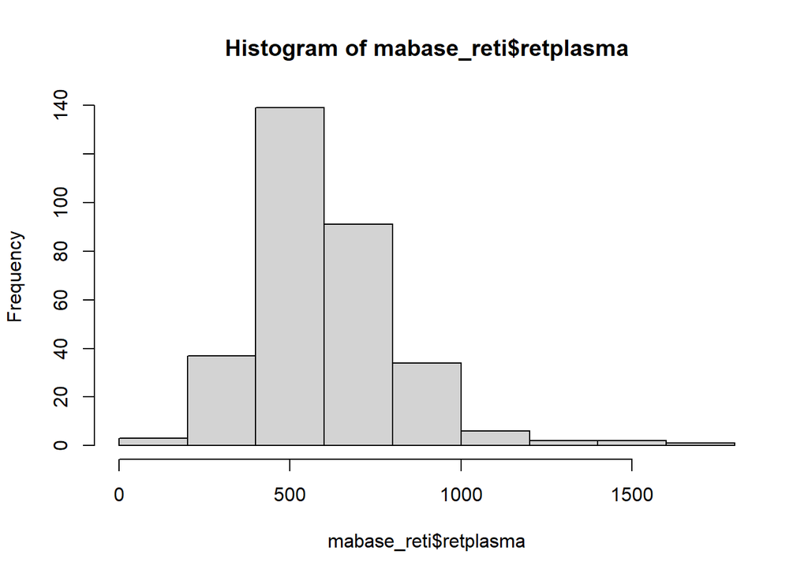

```r
hist(mabase_reti$retplasma)
```

## Test de corrélation

```r
cor.test(x=mabase_reti$retplasma, y= mabase_reti$age)
```

```
##
##  Pearson's product-moment correlation
##
## data:  mabase_reti$retplasma and mabase_reti$age
## t = 3.8317, df = 313, p-value = 0.0001538
## alternative hypothesis: true correlation is not equal to 0
## 95 percent confidence interval:
##  0.1035868 0.3148157
## sample estimates:
##       cor
## 0.2116717
```

## b : Entre le tabagisme et l’age

```r
P2 <- ggplot(mabase_reti,aes(x=tabac,y=age)) + geom_boxplot(aes(fill = tabac)) + geom_point()+ labs(x="Consommation de tabac", y= "Age (en années)")+ scale_x_discrete(labels =c("Jamais","Autrefois", "Actuellement")) +  scale_fill_brewer(palette="Dark2",labels =c("Jamais","Autrefois", "Actuellement"), name = "Statut fumeur")
ggsave("figure_age_tabac.png",P2, dpi = 500)
```

## Vérification de la normailité de la distribution de l’age

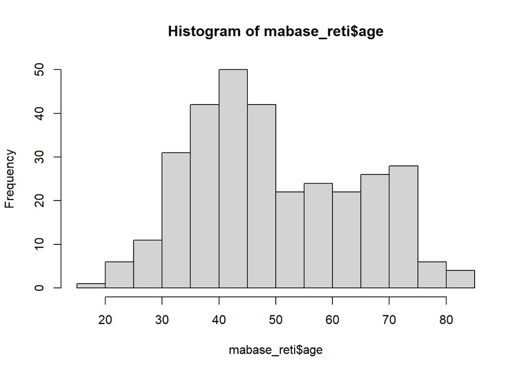

```r
hist(mabase_reti$age)
```

## Vérification de l’égalité des variances d’age entre les groupes de tabac

```r
by(mabase_reti$age,mabase_reti$tabac,sd)
```

```
## mabase_reti$tabac: 1
## [1] 15.02246
## ------------------------------------------------------------
## mabase_reti$tabac: 2
## [1] 13.97244
## ------------------------------------------------------------
## mabase_reti$tabac: 3
## [1] 13.50723
```

## Test anova

```r
model1 <- lm(age~tabac, data = mabase_reti)
anova(model1)
```

```
## Analysis of Variance Table
##
## Response: age
##            Df Sum Sq Mean Sq F value  Pr(>F)
## tabac       2   1581  790.63  3.7878 0.02369 *
## Residuals 312  65124  208.73
## ---
## Signif. codes:  0 '***' 0.001 '**' 0.01 '*' 0.05 '.' 0.1 ' ' 1
```

## Calcul des moyennes d’age

```r
by(mabase_reti$age,mabase_reti$tabac,mean)
```

```
## mabase_reti$tabac: 1
## [1] 51.22293
## ------------------------------------------------------------
## mabase_reti$tabac: 2
## [1] 50.77391
## ------------------------------------------------------------
## mabase_reti$tabac: 3
## [1] 44.53488
```

## c : Entre le sexe et l’age

## Graphique

```r
P1 <- ggplot(mabase_reti,aes(x=sexe,y=age)) + geom_boxplot(aes(fill = sexe))  + labs(x="Sexe", y= "Age (années)")+ scale_x_discrete(labels=c("Maculin","Féminin")) + scale_fill_brewer(palette="Dark2",labels = c("Masculin","Féminin"))
ggsave("figure_age_sexe.png",P1, dpi = 500)
```

## Vérification de la normailité de la distribution de l’age

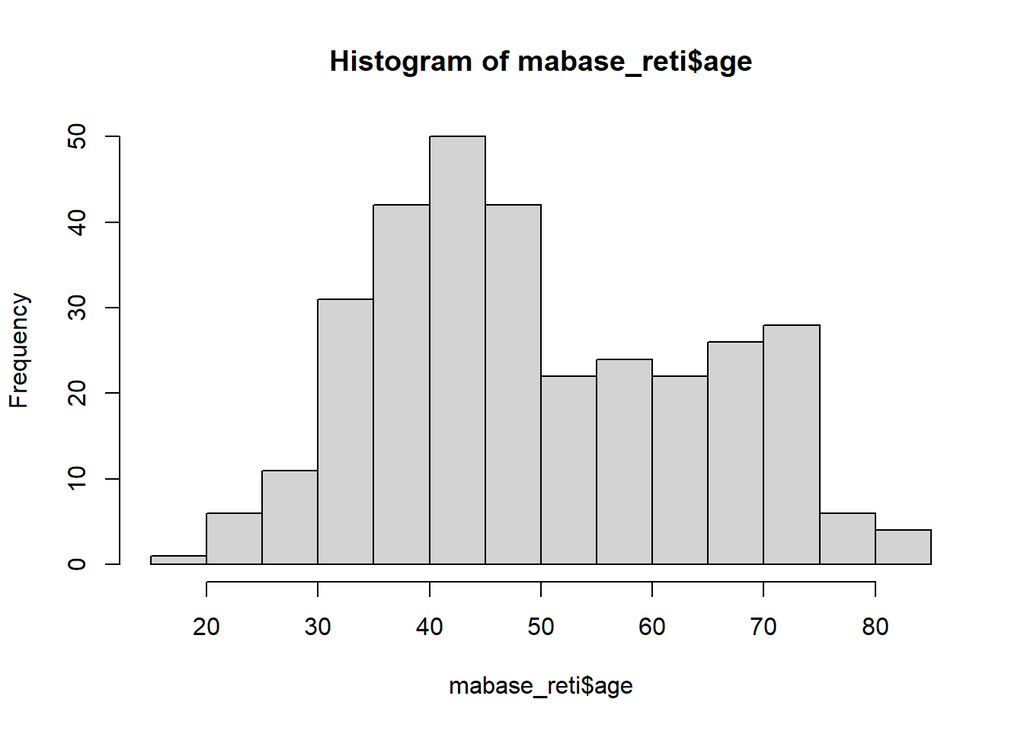

```r
hist(mabase_reti$age)
```

## Vérification des variances d’age entre les sexes

```r
by(mabase_reti$age,mabase_reti$sexe,sd)
```

```
## mabase_reti$sexe: 1
## [1] 13.46939
## ------------------------------------------------------------
## mabase_reti$sexe: 2
## [1] 14.09314
```

## Test t de student

```r
t.test(mabase_reti$age~mabase_reti$sexe,var.equal = TRUE)
```

```
##
##  Two Sample t-test
##
## data:  mabase_reti$age by mabase_reti$sexe
## t = 5.1673, df = 313, p-value = 4.238e-07
## alternative hypothesis: true difference in means between group 1 and group 2 is not equal to 0
## 95 percent confidence interval:
##   7.431882 16.571781
## sample estimates:
## mean in group 1 mean in group 2
##        60.54762        48.54579
```

## d : Entre l’age et le BMI

## Graphique

```r
P3 <- ggplot(mabase_reti,aes(x=mabase_reti$bmi, y= age, colour = sexe)) + geom_point() + labs (x="Indice de masse corporelle", y="Age (années)")+ scale_color_manual(labels = c("Masculin", "Féminin"), values = c("blue","red"))
ggsave("plot_age_imc.png",P3,dpi = 500)
```

## Test de corrélation

```r
cor.test(x=mabase_reti$retplasma, y= mabase_reti$age)
```

[output not shown]

## e : Entre l’age et la consommation alimentaire de vitamines

## Graphique

```r
P4 <- ggplot(mabase_reti,aes(x=vitamine,y=age)) + geom_boxplot(aes(fill=vitamine)) + labs(x="Consommation de vitamines", y= "age (années)")+ scale_x_discrete(labels =c("Oui,souvent","Oui,pas souvent", "Non")) + scale_fill_brewer(palette="Dark2",labels =c("Oui,souvent","Oui,pas souvent", "Non"), name = "Consommation de vitamines")
ggsave("figure_age_vitamines.png",P4, dpi = 500)
```

```r
by(mabase_reti$age,mabase_reti$tabac,sd)
```

[output not shown]

## Test anova

```r
model1 <- lm(age~tabac, data = mabase_reti)
anova(model1)
```

[output not shown]

## Calcul des moyennes d’age par groupe

```r
by(mabase_reti$age,mabase_reti$vitamine,mean)
```

```
## mabase_reti$vitamine: 1
## [1] 51.71311
## ------------------------------------------------------------
## mabase_reti$vitamine: 2
## [1] 46.07317
## ------------------------------------------------------------
## mabase_reti$vitamine: 3
## [1] 51.43243
```

## f : Entre l’age et le taux de cholestérol journalier

## Graphique

```r
P5 <- ggplot(mabase_reti,aes(x=mabase_reti$cholesterol, y= age, colour = sexe)) + geom_point() + labs (x="Cholestérol par jour(mg/jour)", y="Age(années)")+ scale_color_manual(labels = c("Masculin", "Féminin"), values = c("blue","red"))
ggsave("plot_age_chtrl.png",P5,dpi = 500)
```

## Test de corrélation

```r
cor.test(x=mabase_reti$cholesterol, y= mabase_reti$age)
```

```
##
##  Pearson's product-moment correlation
##
## data:  mabase_reti$cholesterol and mabase_reti$age
## t = -2.023, df = 313, p-value = 0.04392
## alternative hypothesis: true correlation is not equal to 0
## 95 percent confidence interval:
##  -0.22133519 -0.00313741
## sample estimates:
##       cor
## -0.113606
```

## g : Entre l’age et le nombre de verres d’alcool consommé par jour

## Graphique

```r
P6 <- ggplot(mabase_reti,aes(x=mabase_reti$alcool, y= age, colour = sexe)) + geom_point() + labs (x="Alcool (verres/jour)", y="Age(années)")+ scale_color_manual(labels = c("Masculin", "Féminin"), values = c("blue","red"))
ggsave("plot_age_alcool.png",P6,dpi = 500)
```

## Test de corrélation

```r
cor.test(x=mabase_reti$alcool, y= mabase_reti$age)
```

```
##
##  Pearson's product-moment correlation
##
## data:  mabase_reti$alcool and mabase_reti$age
## t = 0.91382, df = 313, p-value = 0.3615
## alternative hypothesis: true correlation is not equal to 0
## 95 percent confidence interval:
##  -0.05926249  0.16117247
## sample estimates:
##        cor
## 0.05158327
```

## h : Entre l’age et la quantité de rétinol consommée par jour

## Graphique

```r
P7 <- ggplot(mabase_reti,aes(x=mabase_reti$retdiet, y= age, colour = sexe)) + geom_point() + labs (x="Rétinol (mcg/jour)", y="Age(années)")+ scale_color_manual(labels = c("Masculin", "Féminin"), values = c("blue","red"))
ggsave("plot_age_retdiet.png",P7,dpi = 500)
```

## Test de corrélation

```r
cor.test(x=mabase_reti$retdiet, y= mabase_reti$age)
```

```
##
##  Pearson's product-moment correlation
##
## data:  mabase_reti$retdiet and mabase_reti$age
## t = -0.17004, df = 313, p-value = 0.8651
## alternative hypothesis: true correlation is not equal to 0
## 95 percent confidence interval:
##  -0.1199913  0.1010044
## sample estimates:
##          cor
## -0.009610795
```

## i : Entre l’age et la quantité de rétinol plasmatique

## Graphique

```r
P8 <- ggplot(mabase_reti,aes(x=mabase_reti$retplasma, y= age, colour = sexe)) + geom_point() + labs (x="Rétinol plasmatique(ng/ml)", y="Age(années)")+ scale_color_manual(labels = c("Masculin", "Féminin"), values = c("blue","red"))
ggsave("plot_age_retplas.png",P8,dpi = 500)
```

## Test de corrélation

```r
cor.test(x=mabase_reti$retplasma, y= mabase_reti$age)
```

```
##
##  Pearson's product-moment correlation
##
## data:  mabase_reti$retplasma and mabase_reti$age
## t = 3.8317, df = 313, p-value = 0.0001538
## alternative hypothesis: true correlation is not equal to 0
## 95 percent confidence interval:
##  0.1035868 0.3148157
## sample estimates:
##       cor
## 0.2116717
```

## j- Relation entre le sexe et le statut fumeur

```r
tab1 <- table(mabase_reti$sexe,mabase_reti$tabac)
tab1khi <- chisq.test(tab1)
tab1khi$expected
```

```
##
##             1        2         3
##   1  20.93333 15.33333  5.733333
##   2 136.06667 99.66667 37.266667
```

```r
print(tab1khi)
```

```
##
##  Pearson's Chi-squared test
##
## data:  tab1
## X-squared = 7.1365, df = 2, p-value = 0.0282
```

## k- Relation entre le sexe et l’IMC

## Graphique

```r
P9 <- ggplot(mabase_reti,aes(x=sexe,y=bmi)) + geom_boxplot(aes(fill = sexe))  + labs(x="Sexe", y= "Indice de masse corporelle")+ scale_x_discrete(labels=c("Maculin","Féminin")) + scale_fill_brewer(palette="Dark2",labels = c("Masculin","Féminin"))
ggsave("figure_bmi_sexe.png",P9, dpi = 500)
```

## Verification de l’égalité des variances

```r
by(mabase_reti$bmi,mabase_reti$sexe,sd)
```

```
## mabase_reti$sexe: 1
## [1] 4.17816
## ------------------------------------------------------------
## mabase_reti$sexe: 2
## [1] 6.254042
```

## test t de student

```r
t.test(mabase_reti$bmi~mabase_reti$sexe,var.equal = TRUE)
```

```
##
##  Two Sample t-test
##
## data:  mabase_reti$bmi by mabase_reti$sexe
## t = 0.13175, df = 313, p-value = 0.8953
## alternative hypothesis: true difference in means between group 1 and group 2 is not equal to 0
## 95 percent confidence interval:
##  -1.832703  2.095750
## sample estimates:
## mean in group 1 mean in group 2
##        26.27136        26.13984
```

## l-Sexe vs vitamines

```r
tab2 <- table(mabase_reti$sexe,mabase_reti$vitamine)
tab2khi <- chisq.test(tab2)
tab2khi$expected
```

```
##
##             1        2    3
##   1  16.26667 10.93333 14.8
##   2 105.73333 71.06667 96.2
```

```r
print(tab2khi)
```

```
##
##  Pearson's Chi-squared test
##
## data:  tab2
## X-squared = 11.071, df = 2, p-value = 0.003944
```

## m:Sexe et cholestérol

```r
P10 <- ggplot(mabase_reti,aes(x=sexe,y=mabase_reti$cholesterol)) + geom_boxplot(aes(fill = sexe))  + labs(x="Sexe", y= "Cholesterol (mg/jour)")+ scale_x_discrete(labels=c("Maculin","Féminin")) + scale_fill_brewer(palette="Dark2",labels = c("Masculin","Féminin"))
ggsave("figure_chtrl_sexe.png",P10, dpi = 500)
by(mabase_reti$cholesterol,mabase_reti$sexe,sd)
```

```
## mabase_reti$sexe: 1
## [1] 145.4333
## ------------------------------------------------------------
## mabase_reti$sexe: 2
## [1] 124.9652
```

## Test de de welch

```r
t.test(mabase_reti$cholesterol~mabase_reti$sexe,var.equal = FALSE)
```

```
##
##  Welch Two Sample t-test
##
## data:  mabase_reti$cholesterol by mabase_reti$sexe
## t = 4.1739, df = 50.745, p-value = 0.0001174
## alternative hypothesis: true difference in means between group 1 and group 2 is not equal to 0
## 95 percent confidence interval:
##   51.29455 146.38970
## sample estimates:
## mean in group 1 mean in group 2
##        328.1238        229.2817
```

## n: Sexe vs alcool

```r
P11 <- ggplot(mabase_reti,aes(x=sexe,y=mabase_reti$alcool)) + geom_boxplot(aes(fill = sexe))  + labs(x="Sexe", y= "Alcool (verres/jour)")+ scale_x_discrete(labels=c("Maculin","Féminin")) + scale_fill_brewer(palette="Dark2",labels = c("Masculin","Féminin"))
ggsave("figure_alcool_sexe.png",P11, dpi = 500)
```

## test de Wilcoxon

```r
wilcox.test(mabase_reti$alcool ~ mabase_reti$sexe)
```

```
##
##  Wilcoxon rank sum test with continuity correction
##
## data:  mabase_reti$alcool by mabase_reti$sexe
## W = 6782, p-value = 0.05092
## alternative hypothesis: true location shift is not equal to 0
```

## o: sexe et retdiet

```r
P12 <- ggplot(mabase_reti,aes(x=sexe,y=mabase_reti$retdiet)) + geom_boxplot(aes(fill = sexe))  + labs(x="Sexe", y= "Rétinol consommé (mcg/jour)")+ scale_x_discrete(labels=c("Maculin","Féminin")) + scale_fill_brewer(palette="Dark2",labels = c("Masculin","Féminin"))
ggsave("figure_retdiet_sexe.png",P12, dpi = 500)
```

## test de Wilconxon

```r
wilcox.test(mabase_reti$retdiet ~ mabase_reti$sexe)
```

```
##
##  Wilcoxon rank sum test with continuity correction
##
## data:  mabase_reti$retdiet by mabase_reti$sexe
## W = 6528, p-value = 0.1482
## alternative hypothesis: true location shift is not equal to 0
```

## p:Sexe et retplasma

```r
P13 <- ggplot(mabase_reti,aes(x=sexe,y=mabase_reti$retplasma)) + geom_boxplot(aes(fill = sexe))  + labs(x="Sexe", y= "Rétinol plasmatique (ng/ml)")+ scale_x_discrete(labels=c("Maculin","Féminin")) + scale_fill_brewer(palette="Dark2",labels = c("Masculin","Féminin"))
ggsave("figure_retplasma_sexe.png",P13, dpi = 500)
```

## Egalité des variances

```r
by(mabase_reti$retplasma,mabase_reti$sexe,sd)
```

```
## mabase_reti$sexe: 1
## [1] 307.8088
## ------------------------------------------------------------
## mabase_reti$sexe: 2
## [1] 185.4307
```

## ttest de welch

```r
t.test(mabase_reti$retplasma~mabase_reti$sexe,var.equal=FALSE)
```

```
##
##  Welch Two Sample t-test
##
## data:  mabase_reti$retplasma by mabase_reti$sexe
## t = 2.3157, df = 45.685, p-value = 0.02512
## alternative hypothesis: true difference in means between group 1 and group 2 is not equal to 0
## 95 percent confidence interval:
##   14.76117 211.27180
## sample estimates:
## mean in group 1 mean in group 2
##        700.7381        587.7216
```

## q: Statut fumeur et IMC

## Graphique

```r
P14 <- ggplot(mabase_reti,aes(x=tabac,y=bmi)) + geom_boxplot(aes(fill = tabac))  + labs(x="Statut fumeur", y= "Indice de masse corporelle")+ scale_x_discrete(labels=c("Jamais","Autrefois","Actuellement")) + scale_fill_brewer(palette="Dark2",labels = c("Jamais","Autrefois","Actuellement"),name = "Statut fumeur")
ggsave("figure_tabac_bmi.png",P14, dpi = 500)
```

## Vérification de l’homoscédasticité des variances

```r
by(mabase_reti$bmi,mabase_reti$tabac,sd)
```

```
## mabase_reti$tabac: 1
## [1] 6.864112
## ------------------------------------------------------------
## mabase_reti$tabac: 2
## [1] 4.992464
## ------------------------------------------------------------
## mabase_reti$tabac: 3
## [1] 4.915277
```

## Test anova

```r
model2 <- lm(bmi~tabac, data = mabase_reti)
anova(model2)
```

```
## Analysis of Variance Table
##
## Response: bmi
##            Df  Sum Sq Mean Sq F value Pr(>F)
## tabac       2   148.9  74.441  2.0725 0.1276
## Residuals 312 11206.2  35.917
```

## r : Relation tabac vs vitamines

```r
tab3 <- table(mabase_reti$tabac,mabase_reti$vitamine)
tab3khi <- chisq.test(tab3)
tab3khi$expected
```

```
##
##            1        2        3
##   1 60.80635 40.86984 55.32381
##   2 44.53968 29.93651 40.52381
##   3 16.65397 11.19365 15.15238
```

```r
print(tab3khi)
```

```
##
##  Pearson's Chi-squared test
##
## data:  tab3
## X-squared = 8.8517, df = 4, p-value = 0.06491
```

## s : Relation tabac vs cholestérol; tabac vs alcool

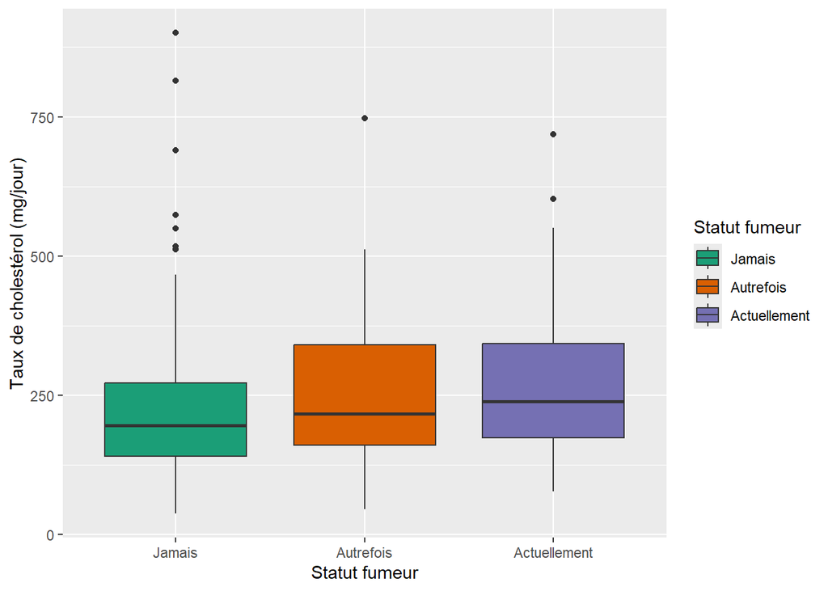

```r
par(mfrow = c(1, 1))
ggplot(mabase_reti,aes(x=tabac,y=cholesterol)) + geom_boxplot(aes(fill = tabac))  + labs(x="Statut fumeur", y= "Taux de cholestérol (mg/jour)")+ scale_x_discrete(labels=c("Jamais","Autrefois","Actuellement")) + scale_fill_brewer(palette="Dark2",labels = c("Jamais","Autrefois","Actuellement"),name = "Statut fumeur")
```

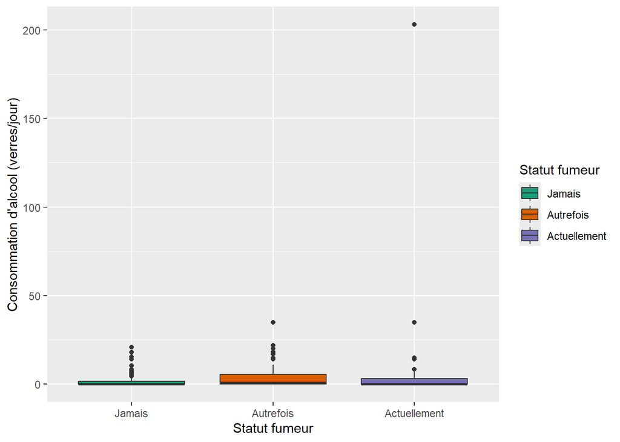

```r
ggplot(mabase_reti,aes(x=tabac,y=alcool)) + geom_boxplot(aes(fill = tabac))  + labs(x="Statut fumeur", y= "Consommation d'alcool (verres/jour)")+ scale_x_discrete(labels=c("Jamais","Autrefois","Actuellement")) + scale_fill_brewer(palette="Dark2",labels = c("Jamais","Autrefois","Actuellement"),name = "Statut fumeur")
```

## Vérification de l’homoscédasticité de la variance du cholestrérol au sein des groupes tabac

```r
by(mabase_reti$cholesterol,mabase_reti$tabac,sd)
```

```
## mabase_reti$tabac: 1
## [1] 134.2284
## ------------------------------------------------------------
## mabase_reti$tabac: 2
## [1] 121.6916
## ------------------------------------------------------------
## mabase_reti$tabac: 3
## [1] 145.9191
```

## test anova avec correction de welch

```r
model3 <- oneway.test(cholesterol~tabac, data = mabase_reti,var.equal=FALSE)
print(model3)
```

```
##
##  One-way analysis of means (not assuming equal variances)
##
## data:  cholesterol and tabac
## F = 2.01, num df = 2.0, denom df = 112.8, p-value = 0.1388
```

## test de Kruskal entre tabac et alcool

```r
kruskal.test(alcool~tabac, mabase_reti)
```

```
##
##  Kruskal-Wallis rank sum test
##
## data:  alcool by tabac
## Kruskal-Wallis chi-squared = 15.501, df = 2, p-value = 0.0004306
```

## Tabac vs retdiet, retplasma

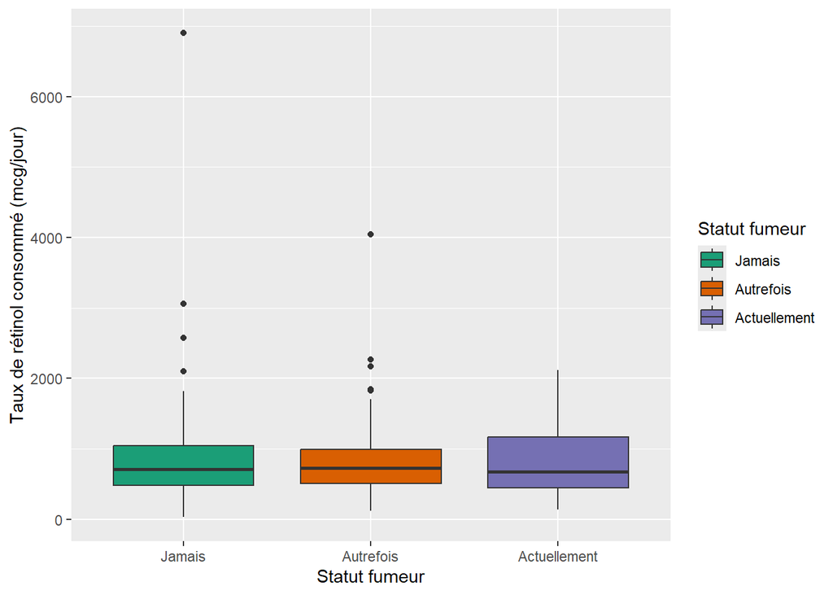

```r
par(mfrow = c(1, 1))
ggplot(mabase_reti,aes(x=tabac,y=retdiet)) + geom_boxplot(aes(fill = tabac))  + labs(x="Statut fumeur", y= "Taux de rétinol consommé (mcg/jour)")+ scale_x_discrete(labels=c("Jamais","Autrefois","Actuellement")) + scale_fill_brewer(palette="Dark2",labels = c("Jamais","Autrefois","Actuellement"),name = "Statut fumeur")
```

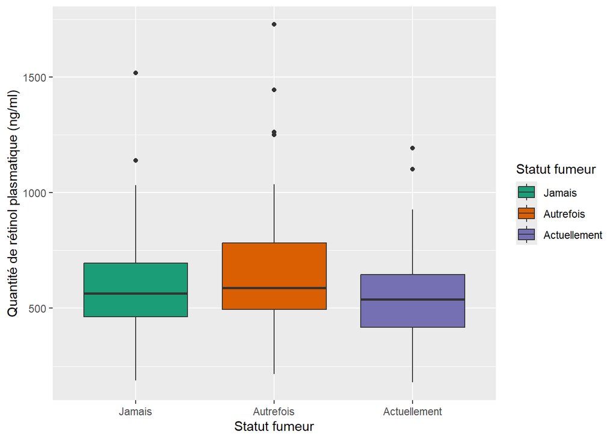

```r
ggplot(mabase_reti,aes(x=tabac,y=retplasma)) + geom_boxplot(aes(fill = tabac))  + labs(x="Statut fumeur", y= "Quantité de rétinol plasmatique (ng/ml)")+ scale_x_discrete(labels=c("Jamais","Autrefois","Actuellement")) + scale_fill_brewer(palette="Dark2",labels = c("Jamais","Autrefois","Actuellement"),name = "Statut fumeur")
```

## Test de kruskal pour tabac vs consommation en rétinol

```r
kruskal.test(retdiet~tabac, mabase_reti)
```

```
##
##  Kruskal-Wallis rank sum test
##
## data:  retdiet by tabac
## Kruskal-Wallis chi-squared = 0.31461, df = 2, p-value = 0.8544
```

## Vérification de l’égalité des variances de retplasma dans les groupes tabac

```r
by(mabase_reti$retplasma,mabase_reti$tabac,sd)
```

```
## mabase_reti$tabac: 1
## [1] 187.6431
## ------------------------------------------------------------
## mabase_reti$tabac: 2
## [1] 231.1676
## ------------------------------------------------------------
## mabase_reti$tabac: 3
## [1] 206.5778
```

## Anova avec correction de Welch, tabac vs retplasma

```r
model4 <- oneway.test(retplasma~tabac, data = mabase_reti,var.equal=FALSE)
print(model4)
```

```
##
##  One-way analysis of means (not assuming equal variances)
##
## data:  retplasma and tabac
## F = 3.3771, num df = 2.00, denom df = 113.25, p-value = 0.03762
```

## t: IMC vs vitamines

## Graphique

```r
P15 <- ggplot(mabase_reti,aes(x=vitamine,y=mabase_reti$bmi)) + geom_boxplot(aes(fill = vitamine))  + labs(x="Consommation en vitamines", y= "IMC")+ scale_x_discrete(labels=c("Oui, souvent","Oui, pas souvent", "Non")) + scale_fill_brewer(palette="Dark2",labels = c("Oui, souvent","Oui, pas souvent", "Non"), name = "Consommation de vitamines")
ggsave("figure_imc_vit.png",P15, dpi = 500)
```

## Vérification de l’égalite des variances

```r
by(mabase_reti$bmi,mabase_reti$vitamine,sd)
```

```
## mabase_reti$vitamine: 1
## [1] 5.814366
## ------------------------------------------------------------
## mabase_reti$vitamine: 2
## [1] 6.46127
## ------------------------------------------------------------
## mabase_reti$vitamine: 3
## [1] 5.875877
```

## Test anova

```r
model5 <- lm(bmi~vitamine, data = mabase_reti)
anova(model5)
```

```
## Analysis of Variance Table
##
## Response: bmi
##            Df Sum Sq Mean Sq F value Pr(>F)
## vitamine    2     85  42.522  1.1772 0.3095
## Residuals 312  11270  36.122
```

## U: IMC vs cholestérol, alcool, retdiet, retplasma

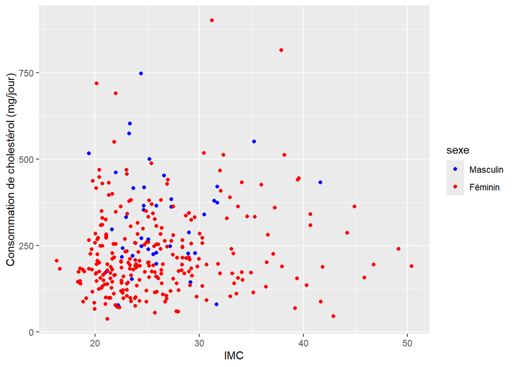

```r
par(mfrow = c(2, 2))
ggplot(mabase_reti,aes(x=mabase_reti$bmi, y= cholesterol, colour = sexe)) + geom_point() + labs (x="IMC", y="Consommation de cholestérol (mg/jour)")+ scale_color_manual(labels = c("Masculin", "Féminin"), values = c("blue","red"))
```

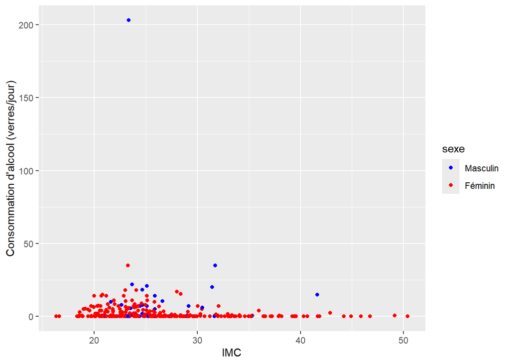

```r
ggplot(mabase_reti,aes(x=mabase_reti$bmi, y= alcool, colour = sexe)) + geom_point() + labs (x="IMC", y="Consommation d'alcool (verres/jour)")+ scale_color_manual(labels = c("Masculin", "Féminin"), values = c("blue","red"))
```

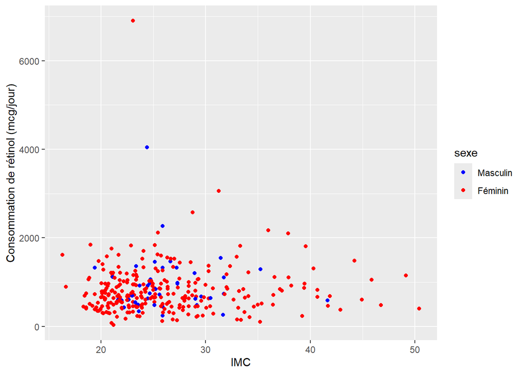

```r
ggplot(mabase_reti,aes(x=mabase_reti$bmi, y= retdiet, colour = sexe)) + geom_point() + labs (x="IMC", y="Consommation de rétinol (mcg/jour)")+ scale_color_manual(labels = c("Masculin", "Féminin"), values = c("blue","red"))
```

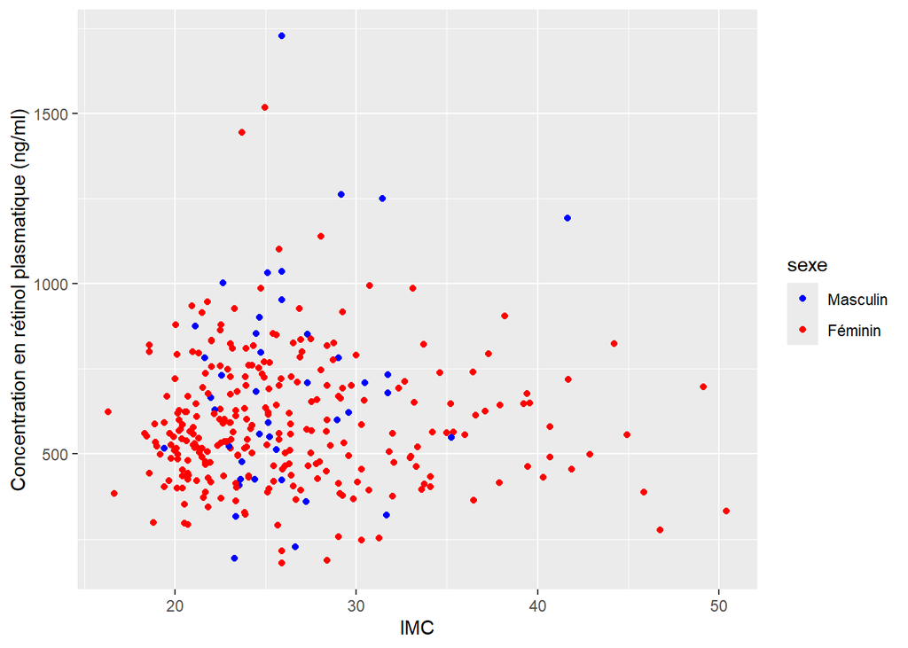

```r
ggplot(mabase_reti,aes(x=mabase_reti$bmi, y= retplasma, colour = sexe)) + geom_point() + labs (x="IMC", y="Concentration en rétinol plasmatique (ng/ml)")+ scale_color_manual(labels = c("Masculin", "Féminin"), values = c("blue","red"))
```

## tests de corrélation de Pearson

```r
cor.test(x=mabase_reti$bmi, y= mabase_reti$cholesterol)
```

```
##
##  Pearson's product-moment correlation
##
## data:  mabase_reti$bmi and mabase_reti$cholesterol
## t = 1.9626, df = 313, p-value = 0.05058
## alternative hypothesis: true correlation is not equal to 0
## 95 percent confidence interval:
##  -0.0002537915  0.2181076989
## sample estimates:
##       cor
## 0.1102572
```

```r
cor.test(x=mabase_reti$bmi, y= mabase_reti$alcool)
```

```
##
##  Pearson's product-moment correlation
##
## data:  mabase_reti$bmi and mabase_reti$alcool
## t = -1.2895, df = 313, p-value = 0.1982
## alternative hypothesis: true correlation is not equal to 0
## 95 percent confidence interval:
##  -0.18174335  0.03811874
## sample estimates:
##         cor
## -0.07269543
```

```r
cor.test(x=mabase_reti$bmi, y= mabase_reti$retdiet)
```

```
##
##  Pearson's product-moment correlation
##
## data:  mabase_reti$bmi and mabase_reti$retdiet
## t = 0.56742, df = 313, p-value = 0.5708
## alternative hypothesis: true correlation is not equal to 0
## 95 percent confidence interval:
##  -0.07873106  0.14206049
## sample estimates:
##        cor
## 0.03205578
```

```r
cor.test(x=mabase_reti$bmi, y= mabase_reti$retplasma)
```

```
##
##  Pearson's product-moment correlation
##
## data:  mabase_reti$bmi and mabase_reti$retplasma
## t = 0.23247, df = 313, p-value = 0.8163
## alternative hypothesis: true correlation is not equal to 0
## 95 percent confidence interval:
##  -0.09751087  0.12346733
## sample estimates:
##        cor
## 0.01313865
```

## u: Relation entre la consommation de vitamines et les quantités de cholestérol et de retplasma

#Graphique

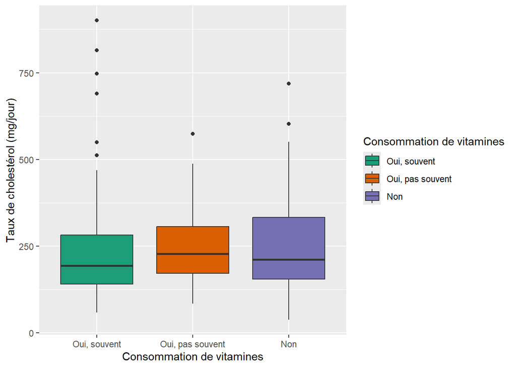

```r
par(mfrow = c(1, 1))
ggplot(mabase_reti,aes(x=vitamine,y=cholesterol)) + geom_boxplot(aes(fill = vitamine))  + labs(x="Consommation de vitamines", y= "Taux de cholestérol (mg/jour)")+ scale_x_discrete(labels=c("Oui, souvent","Oui, pas souvent","Non")) + scale_fill_brewer(palette="Dark2",labels = c("Oui, souvent","Oui, pas souvent","Non"),name = "Consommation de vitamines")
```

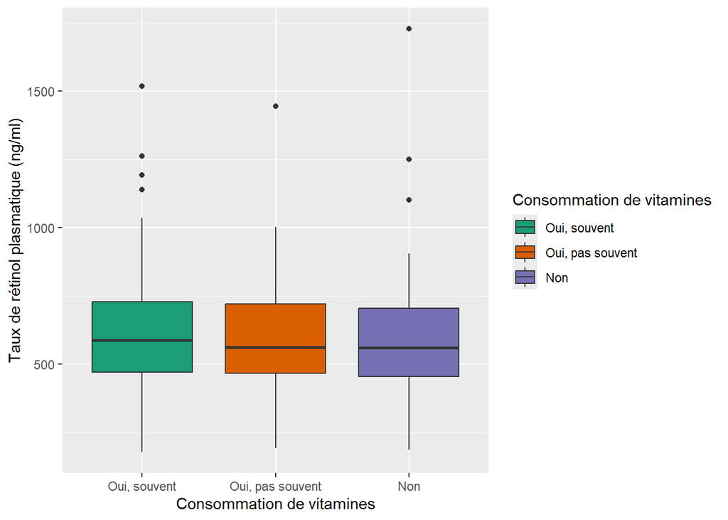

```r
ggplot(mabase_reti,aes(x=vitamine,y=retplasma)) + geom_boxplot(aes(fill = vitamine))  + labs(x="Consommation de vitamines", y= "Taux de rétinol plasmatique (ng/ml)")+ scale_x_discrete(labels=c("Oui, souvent","Oui, pas souvent","Non")) + scale_fill_brewer(palette="Dark2",labels = c("Oui, souvent","Oui, pas souvent","Non"),name = "Consommation de vitamines")
```

## Egalité des variances

```r
by(mabase_reti$cholesterol,mabase_reti$vitamine,sd)
```

```
## mabase_reti$vitamine: 1
## [1] 151.0982
## ------------------------------------------------------------
## mabase_reti$vitamine: 2
## [1] 99.62849
## ------------------------------------------------------------
## mabase_reti$vitamine: 3
## [1] 131.3305
```

```r
by(mabase_reti$retplasma,mabase_reti$vitamine,sd)
```

```
## mabase_reti$vitamine: 1
## [1] 223.8304
## ------------------------------------------------------------
## mabase_reti$vitamine: 2
## [1] 192.0211
## ------------------------------------------------------------
## mabase_reti$vitamine: 3
## [1] 205.2004
```

## ANOVA avec correction de Welch

```r
model6 <- oneway.test(cholesterol~vitamine, data = mabase_reti,var.equal=FALSE)
print(model6)
```

```
##
##  One-way analysis of means (not assuming equal variances)
##
## data:  cholesterol and vitamine
## F = 0.16982, num df = 2.00, denom df = 206.73, p-value = 0.8439
```

```r
model7 <- oneway.test(retplasma~vitamine, data = mabase_reti,var.equal=FALSE)
print(model7)
```

```
##
##  One-way analysis of means (not assuming equal variances)
##
## data:  retplasma and vitamine
## F = 0.23208, num df = 2.00, denom df = 199.87, p-value = 0.7931
```

#Graphiques

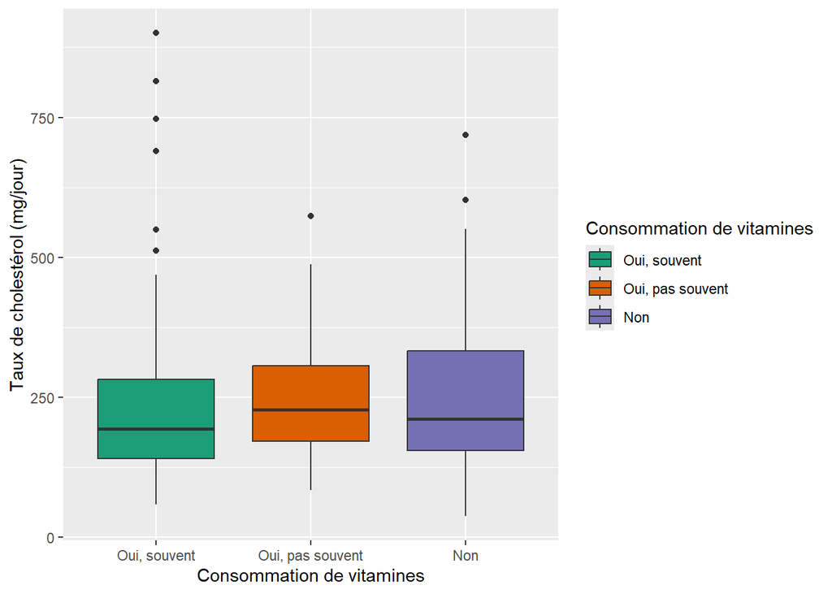

```r
par(mfrow = c(1, 1))
ggplot(mabase_reti,aes(x=vitamine,y=cholesterol)) + geom_boxplot(aes(fill = vitamine))  + labs(x="Consommation de vitamines", y= "Taux de cholestérol (mg/jour)")+ scale_x_discrete(labels=c("Oui, souvent","Oui, pas souvent","Non")) + scale_fill_brewer(palette="Dark2",labels = c("Oui, souvent","Oui, pas souvent","Non"),name = "Consommation de vitamines")
```

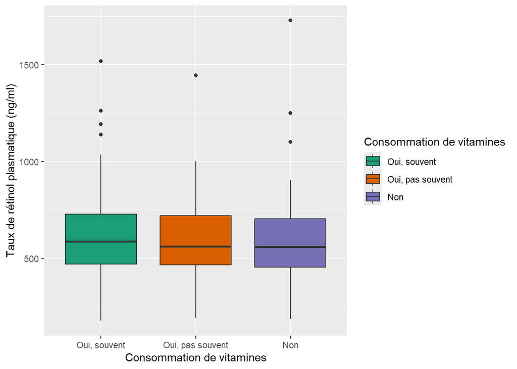

```r
ggplot(mabase_reti,aes(x=vitamine,y=retplasma)) + geom_boxplot(aes(fill = vitamine))  + labs(x="Consommation de vitamines", y= "Taux de rétinol plasmatique (ng/ml)")+ scale_x_discrete(labels=c("Oui, souvent","Oui, pas souvent","Non")) + scale_fill_brewer(palette="Dark2",labels = c("Oui, souvent","Oui, pas souvent","Non"),name = "Consommation de vitamines")
```

## Tests de kruskal-Wallis

```r
kruskal.test(alcool~vitamine, mabase_reti)
```

```
##
##  Kruskal-Wallis rank sum test
##
## data:  alcool by vitamine
## Kruskal-Wallis chi-squared = 6.5121, df = 2, p-value = 0.03854
```

```r
kruskal.test(retplasma~vitamine, mabase_reti)
```

```
##
##  Kruskal-Wallis rank sum test
##
## data:  retplasma by vitamine
## Kruskal-Wallis chi-squared = 0.39485, df = 2, p-value = 0.8208
```

## w : Relation entre la quantité de cholestérol et la prise d’alcool, le taux de rétinol consommé et le taux de rétinol plasmatique

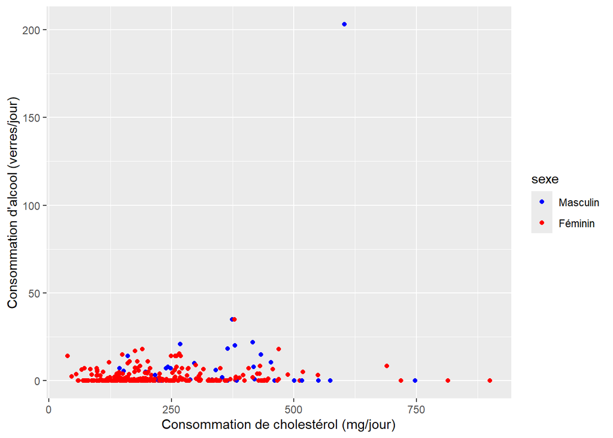

```r
ggplot(mabase_reti,aes(x=mabase_reti$cholesterol, y= alcool, colour = sexe)) + geom_point() + labs (x="Consommation de cholestérol (mg/jour)", y="Consommation d'alcool (verres/jour)")+ scale_color_manual(labels = c("Masculin", "Féminin"), values = c("blue","red"))
```

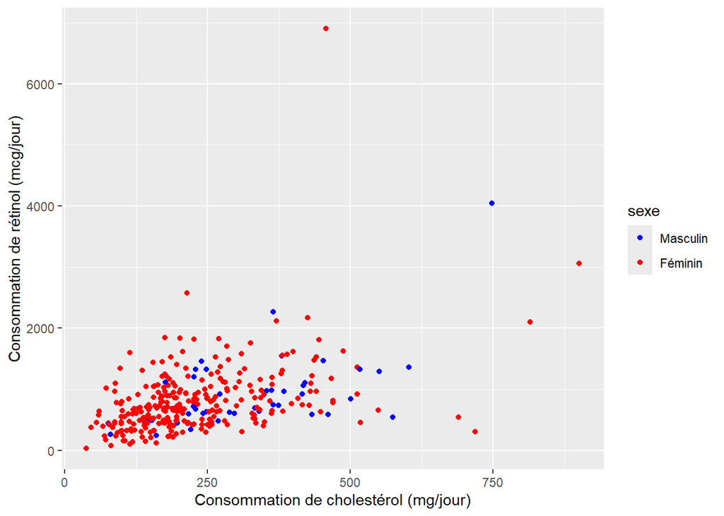

```r
ggplot(mabase_reti,aes(x=mabase_reti$cholesterol, y= retdiet, colour = sexe)) + geom_point() + labs (x="Consommation de cholestérol (mg/jour)", y="Consommation de rétinol (mcg/jour)")+ scale_color_manual(labels = c("Masculin", "Féminin"), values = c("blue","red"))
```

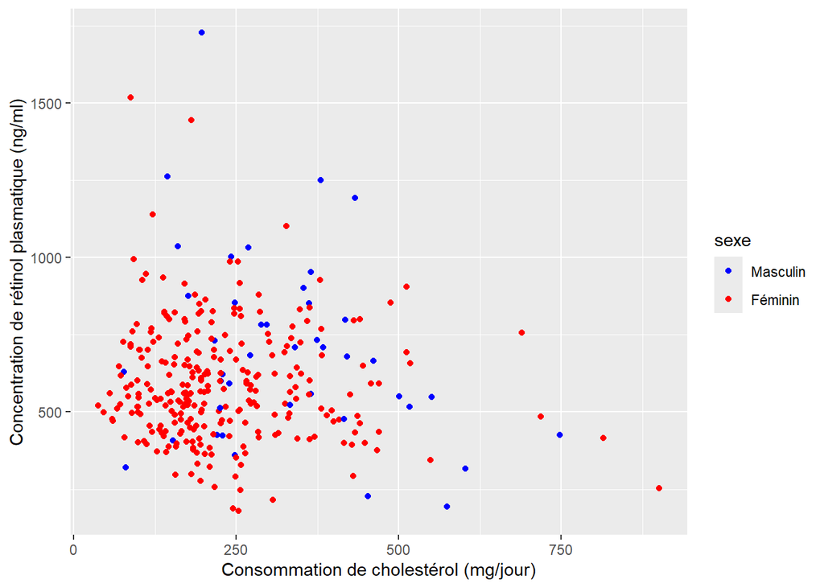

```r
ggplot(mabase_reti,aes(x=mabase_reti$cholesterol, y= retplasma, colour = sexe)) + geom_point() + labs (x="Consommation de cholestérol (mg/jour)", y="Concentration de rétinol plasmatique (ng/ml)")+ scale_color_manual(labels = c("Masculin", "Féminin"), values = c("blue","red"))
```

## test dd nullité de la corrélation de Pearson

```r
cor.test(x=mabase_reti$cholesterol, y= mabase_reti$alcool)
```

```
##
##  Pearson's product-moment correlation
##
## data:  mabase_reti$cholesterol and mabase_reti$alcool
## t = 3.2795, df = 313, p-value = 0.001157
## alternative hypothesis: true correlation is not equal to 0
## 95 percent confidence interval:
##  0.07323103 0.28699146
## sample estimates:
##      cor
## 0.182264
```

```r
cor.test(x=mabase_reti$cholesterol, y= mabase_reti$retdiet)
```

```
##
##  Pearson's product-moment correlation
##
## data:  mabase_reti$cholesterol and mabase_reti$retdiet
## t = 8.7529, df = 313, p-value < 2.2e-16
## alternative hypothesis: true correlation is not equal to 0
## 95 percent confidence interval:
##  0.3500869 0.5280699
## sample estimates:
##       cor
## 0.4434393
```

```r
cor.test(x=mabase_reti$cholesterol, y= mabase_reti$retplasma)
```

```
##
##  Pearson's product-moment correlation
##
## data:  mabase_reti$cholesterol and mabase_reti$retplasma
## t = -1.2451, df = 313, p-value = 0.214
## alternative hypothesis: true correlation is not equal to 0
## 95 percent confidence interval:
##  -0.17931817  0.04062174
## sample estimates:
##         cor
## -0.07020134
```